# 808W Final Project

Aman Geetey (116087599), Pranav P. Jaipurkar (115798120)

12/1/2018

Comment: Importing and Reading datasets-

```r
cwur <- read.csv("~/Desktop/Data Science 808W/My Project/world-university-rankings/cwurData.csv")
View(cwur)

education_expenditure_supplementary_data <- read.csv("~/Desktop/Data Science 808W/My Project/world-university-rankings/education_expenditure_supplementary_data.csv")
View(education_expenditure_supplementary_data)

school_and_country_table <- read.csv("~/Desktop/Data Science 808W/My Project/world-university-rankings/school_and_country_table.csv")
View(school_and_country_table)

shanghai <- read.csv("~/Desktop/Data Science 808W/My Project/world-university-rankings/shanghaiData.csv")
View(shanghai)

times <- read.csv("~/Desktop/Data Science 808W/My Project/world-university-rankings/timesData.csv")
View(times)
```

Comment: Analyzing the dataset

```r
levels(cwur$country)
```

```
##  [1] "Argentina"            "Australia"            "Austria"
##  [4] "Belgium"              "Brazil"               "Bulgaria"
##  [7] "Canada"               "Chile"                "China"
## [10] "Colombia"             "Croatia"              "Cyprus"
## [13] "Czech Republic"       "Denmark"              "Egypt"
## [16] "Estonia"              "Finland"              "France"
## [19] "Germany"              "Greece"               "Hong Kong"
## [22] "Hungary"              "Iceland"              "India"
## [25] "Iran"                 "Ireland"              "Israel"
## [28] "Italy"                "Japan"                "Lebanon"
## [31] "Lithuania"            "Malaysia"             "Mexico"
## [34] "Netherlands"          "New Zealand"          "Norway"
## [37] "Poland"               "Portugal"             "Puerto Rico"
## [40] "Romania"              "Russia"               "Saudi Arabia"
## [43] "Serbia"               "Singapore"            "Slovak Republic"
## [46] "Slovenia"             "South Africa"         "South Korea"
## [49] "Spain"                "Sweden"               "Switzerland"
## [52] "Taiwan"               "Thailand"             "Turkey"
## [55] "Uganda"               "United Arab Emirates" "United Kingdom"
## [58] "Uruguay"              "USA"
```

Comment: There are 59 countries in cwur dataset.

```r
sum(is.na(cwur))
```

```
## [1] 200
```

```r
sum(is.na(cwur$broad_impact))
```

```
## [1] 200
```

Comment: Broad impact column has 200 missing values

```r
summary(cwur$country)
```

```
##            Argentina            Australia              Austria
##                    7                   58                   24
##              Belgium               Brazil             Bulgaria
##                   20                   36                    2
##               Canada                Chile                China
##                   72                    8                  167
##             Colombia              Croatia               Cyprus
##                    4                    2                    2
##       Czech Republic              Denmark                Egypt
##                   10                   12                    8
##              Estonia              Finland               France
##                    2                   20                  109
##              Germany               Greece            Hong Kong
##                  115                   14                   12
##              Hungary              Iceland                India
##                   12                    2                   31
##                 Iran              Ireland               Israel
##                   16                   16                   22
##                Italy                Japan              Lebanon
##                   96                  159                    2
##            Lithuania             Malaysia               Mexico
##                    2                    6                    4
##          Netherlands          New Zealand               Norway
##                   29                   12                   12
##               Poland             Portugal          Puerto Rico
##                   18                   14                    2
##              Romania               Russia         Saudi Arabia
##                    3                    9                    8
##               Serbia            Singapore      Slovak Republic
##                    2                    5                    2
##             Slovenia         South Africa          South Korea
##                    4                   10                   72
##                Spain               Sweden          Switzerland
##                   81                   24                   26
##               Taiwan             Thailand               Turkey
##                   46                    6                   20
##               Uganda United Arab Emirates       United Kingdom
##                    2                    2                  144
##              Uruguay                  USA
##                    2                  573
```

Comment: Maximum universities in this dataset are from USA.

```r
range(cwur$world_rank)
```

```
## [1]    1 1000
```

```r
mean(cwur$score[cwur$country == "USA"])
```

```
## [1] 51.83986
```

```r
mean(cwur$score[cwur$country == "India"])
```

```
## [1] 44.71323
```

```r
mean(cwur$score[cwur$country == "United Kingdom"])
```

```
## [1] 49.47465
```

Comment: Mean score for USA is greater than mean score for UK which is greater than mean score for India.

```r
range(cwur$patents)
```

```
## [1]   1 871
```

```r
range(cwur$year)
```

```
## [1] 2012 2015
```

Comment: cwur has data recorded from year 2012 to 2015.

```r
levels(education_expenditure_supplementary_data$direct_expenditure_type)
```

```
## [1] "Private" "Public"  "Total"
```

Comment: There are 3 types of direct expenditure.

```r
sum(education_expenditure_supplementary_data$direct_expenditure_type == "Public")
```

```
## [1] 111
```

```r
sum(education_expenditure_supplementary_data$direct_expenditure_type == "Private")
```

```
## [1] 111
```

```r
sum(education_expenditure_supplementary_data$direct_expenditure_type == "Total")
```

```
## [1] 111
```

```r
sum(is.na(times))
```

```
## [1] 59
```

```r
levels(times$world_rank)
```

```
##   [1] "=101"    "=104"    "=106"    "=110"    "=113"    "=120"    "=123"
##   [8] "=125"    "=127"    "=131"    "=133"    "=138"    "=144"    "=149"
##  [15] "=158"    "=161"    "=164"    "=167"    "=172"    "=176"    "=180"
##  [22] "=182"    "=185"    "=190"    "=193"    "=196"    "=39"     "=44"
##  [29] "=47"     "=56"     "=60"     "=65"     "=76"     "=82"     "=88"
##  [36] "=90"     "=94"     "=99"     "1"       "10"      "100"     "101"
##  [43] "102"     "103"     "104"     "105"     "106"     "107"     "108"
##  [50] "109"     "11"      "110"     "111"     "112"     "113"     "114"
##  [57] "115"     "116"     "117"     "118"     "119"     "12"      "120"
##  [64] "121"     "122"     "123"     "124"     "125"     "126"     "127"
##  [71] "128"     "129"     "13"      "130"     "131"     "132"     "133"
##  [78] "134"     "135"     "136"     "137"     "138"     "139"     "14"
##  [85] "140"     "141"     "142"     "143"     "144"     "145"     "146"
##  [92] "147"     "148"     "149"     "15"      "150"     "151"     "152"
##  [99] "153"     "154"     "155"     "156"     "157"     "158"     "159"
```

[output cut: 21 more lines]

```r
levels(times$country)
```

```
##  [1] "Argentina"                 "Australia"
##  [3] "Austria"                   "Bangladesh"
##  [5] "Belarus"                   "Belgium"
##  [7] "Brazil"                    "Canada"
##  [9] "Chile"                     "China"
## [11] "Colombia"                  "Cyprus"
## [13] "Czech Republic"            "Denmark"
## [15] "Egypt"                     "Estonia"
## [17] "Finland"                   "France"
## [19] "Germany"                   "Ghana"
## [21] "Greece"                    "Hong Kong"
## [23] "Hungary"                   "Iceland"
## [25] "India"                     "Indonesia"
## [27] "Iran"                      "Israel"
## [29] "Italy"                     "Japan"
```

[output cut: 21 more lines]

Comment: There are 72 countries in times dataset.

```r
range(times$year)
```

```
## [1] 2011 2016
```

Comment: Times dataset has data recorded from 2011 to 2016.

```r
sum(is.na(shanghai))
```

```
## [1] 3827
```

```r
levels(shanghai$world_rank)
```

```
##   [1] "1"       "10"      "100"     "101-150" "101-151" "101-152" "102-150"
##   [8] "11"      "12"      "13"      "14"      "15"      "151-200" "151-202"
##  [15] "152-200" "153-202" "16"      "17"      "18"      "19"      "2"
##  [22] "20"      "201-300" "201-302" "203-300" "203-304" "21"      "22"
##  [29] "23"      "24"      "25"      "26"      "27"      "28"      "29"
##  [36] "3"       "30"      "301-400" "303-401" "305-402" "31"      "32"
##  [43] "33"      "34"      "35"      "36"      "37"      "38"      "39"
##  [50] "4"       "40"      "401-500" "402-501" "402-503" "403-510" "41"
##  [57] "42"      "43"      "44"      "45"      "46"      "47"      "48"
##  [64] "49"      "5"       "50"      "51"      "52"      "53"      "54"
##  [71] "55"      "56"      "57"      "58"      "59"      "6"       "60"
##  [78] "61"      "62"      "63"      "64"      "65"      "66"      "67"
##  [85] "68"      "69"      "7"       "70"      "71"      "72"      "73"
##  [92] "74"      "75"      "76"      "77"      "78"      "79"      "8"
##  [99] "80"      "81"      "82"      "83"      "84"      "85"      "86"
## [106] "87"      "88"      "89"      "9"       "90"      "91"      "92"
## [113] "93"      "94"      "95"      "96"      "97"      "98"      "99"
```

```r
range(shanghai$year)
```

```
## [1] 2005 2015
```

Comment: Shanghai dataset has data recorded from year 2005 to 2015.

According to my initial analysis of data, I would be taking cwur data and times dataset for further analysis and model making.

Visualization

```r
library(tibble)
library(ggplot2)
x <- c(education_expenditure_supplementary_data$direct_expenditure_type)
table(x)
```

```
## x
##   1   2   3
## 111 111 111
```

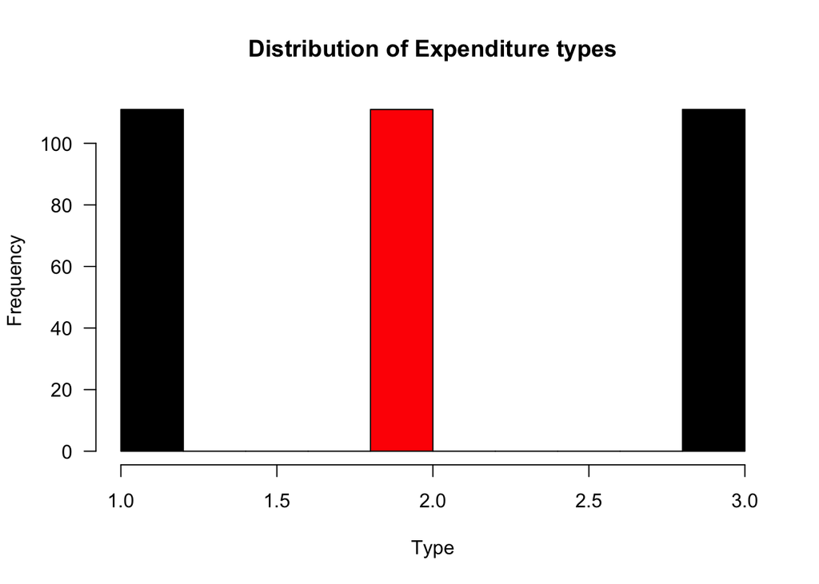

```r
hist(x, col = 1:3, main = "Distribution of Expenditure types", las = 1, xlab = "Type")
```

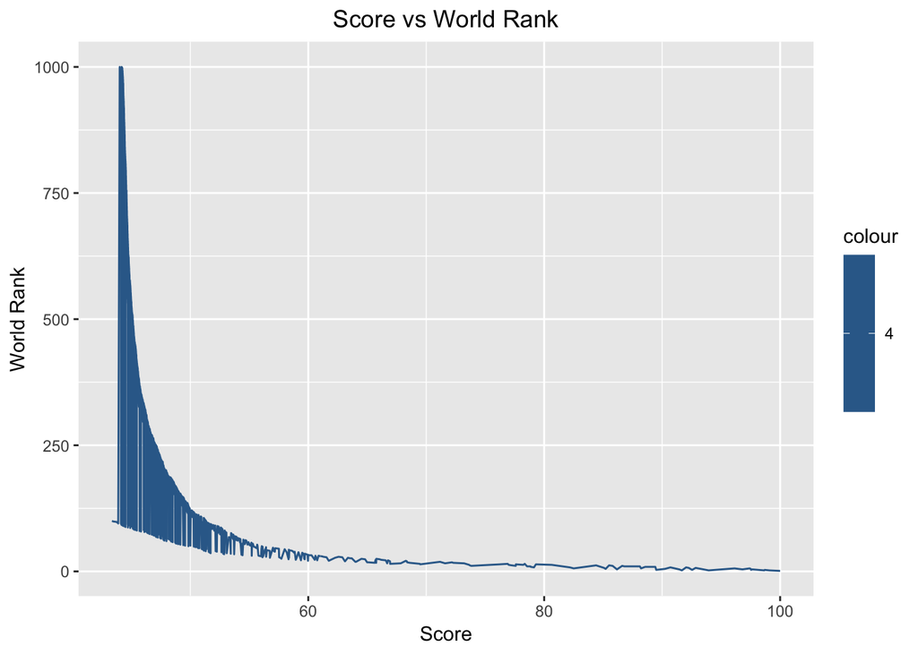

```r
ggplot(cwur, aes(score, world_rank, col = 4)) +
  geom_line() + ggtitle("Score vs World Rank") + theme(plot.title = element_text(hjust = 0.5)) + xlab("Score") + ylab("World Rank")
```

```r
library(dplyr)
library(tidyr)
library(stringr)

partc <- select(cwur, institution, country, alumni_employment, citations, world_rank, year)

summarise(partc, num_universities = n_distinct(institution))
```

```
##   num_universities
## 1             1024
```

```r
summarise(partc, num_countries = n_distinct(country))
```

```
##   num_countries
## 1            59
```

```r
paste0("Number of NA cells = ", sum(is.na(partc)))
```

```
## [1] "Number of NA cells = 0"
```

```r
partc <- mutate_each(partc, funs(as.numeric), alumni_employment, citations, world_rank)
```

```
## `mutate_each()` is deprecated.
## Use `mutate_all()`, `mutate_at()` or `mutate_if()` instead.
## To map `funs` over a selection of variables, use `mutate_at()`
```

```r
med.R <- partc %>%
  group_by(institution, country) %>%
  summarise_each(funs(median), alumni_employment, citations, world_rank)
```

```
## `summarise_each()` is deprecated.
## Use `summarise_all()`, `summarise_at()` or `summarise_if()` instead.
## To map `funs` over a selection of variables, use `summarise_at()`
```

```r
head(med.R)
```

```
## # A tibble: 6 x 5
## # Groups:   institution [6]
##   institution             country    alumni_employme… citations world_rank
##   <fct>                   <fct>                 <dbl>     <dbl>      <dbl>
## 1 Aalborg University      Denmark                412.       325       579
## 2 Aalto University        Finland                238.       627       406.
## 3 Aarhus University       Denmark                176.        91       120.
## 4 Aberystwyth University  United Ki…             522.       502       807
## 5 Åbo Akademi University  Finland                522.       627       716.
## 6 Adam Mickiewicz Univer… Poland                 522.       806       884
```

```r
high.rank <- filter(med.R, alumni_employment < 100, citations < 100)


high.rank %>%
  group_by(Country = country) %>%
  summarise(Count = n()) %>%
  arrange(desc(Count))
```

```
## # A tibble: 10 x 2
##    Country        Count
##    <fct>          <int>
##  1 USA               36
##  2 United Kingdom     4
##  3 Japan              3
##  4 Canada             2
##  5 Switzerland        2
##  6 China              1
##  7 Netherlands        1
##  8 Singapore          1
##  9 South Korea        1
## 10 Sweden             1
```

```r
high.rank$institution <- str_replace(high.rank$institution, 'University', 'Univ.')
high.rank$institution <- str_replace(high.rank$institution, 'Massachusetts Institute of Technology', 'MIT')
high.rank$institution <- str_replace(high.rank$institution, 'California', 'Cal.')
high.rank$institution <- str_replace(high.rank$institution, 'Michigan', 'Mich.')
high.rank$country <- str_replace(high.rank$country, 'United Kingdom', 'UK')
high.rank$country <- str_replace(high.rank$country, 'South Korea', 'S. Korea')

head(arrange(high.rank, alumni_employment), 15)
```

```
## # A tibble: 15 x 5
## # Groups:   institution [15]
##    institution           country  alumni_employment citations world_rank
##    <chr>                 <chr>                <dbl>     <dbl>      <dbl>
##  1 Harvard Univ.         USA                    1         1          1
##  2 Stanford Univ.        USA                    2         2.5        2
##  3 Univ. of Tokyo        Japan                  3        28.5       13.5
##  4 Univ. of Pennsylvania USA                    4.5      11         13.5
##  5 Columbia Univ.        USA                    8        11          6
##  6 Seoul National Univ.  S. Korea              11        81.5       32
##  7 Univ. of Cambridge    UK                    12.5      11.5        4
##  8 Univ. of Oxford       UK                    12.5      12          5
##  9 MIT                   USA                   13.5       2.5        3
## 10 Princeton Univ.       USA                   14.5      25          8.5
## 11 Univ. of Chicago      USA                   16.5      20          8.5
## 12 Northwestern Univ.    USA                   17        24.5       25.5
## 13 Kyoto Univ.           Japan                 20        59.5       16.5
## 14 Cornell Univ.         USA                   20.5      19.5       11.5
## 15 Univ. of Virginia     USA                   22        62.5       56
```

```r
high.rank$institution <- str_replace(high.rank$institution, 'Federal Institute of Technology', 'FIT')

head(high.rank %>% filter(country != 'USA') %>% arrange(alumni_employment), 15)
```

```
## # A tibble: 15 x 5
## # Groups:   institution [15]
##    institution           country     alumni_employme… citations world_rank
##    <chr>                 <chr>                  <dbl>     <dbl>      <dbl>
##  1 Univ. of Tokyo        Japan                    3        28.5       13.5
##  2 Seoul National Univ.  S. Korea                11        81.5       32
##  3 Univ. of Cambridge    UK                      12.5      11.5        4
##  4 Univ. of Oxford       UK                      12.5      12          5
##  5 Kyoto Univ.           Japan                   20        59.5       16.5
##  6 McGill Univ.          Canada                  49.5      45.5       42
##  7 Erasmus Univ. Rotter… Netherlands             56        64         93
##  8 Osaka Univ.           Japan                   65        93         39
##  9 Swiss FIT in Zurich   Switzerland             65        44.5       18
## 10 Univ. of Toronto      Canada                  66        12.5       31.5
## 11 Tsinghua Univ.        China                   68        99.5       82.5
## 12 Imperial College Lon… UK                      87        26         31.5
## 13 Swiss FIT in Lausanne Switzerland             87.5      65.5       87
## 14 Stockholm Univ.       Sweden                  92.5      93.5      178.
## 15 Univ. of Manchester   UK                      96.5      50         70.5
```

Creating a new object with cwur data for correlation analysis

```r
newpQData <- cwur
newpQData <- newpQData[,-c(2, 3, 4, 11)]
```

Comment: Creating graphs to find correlation between pairs

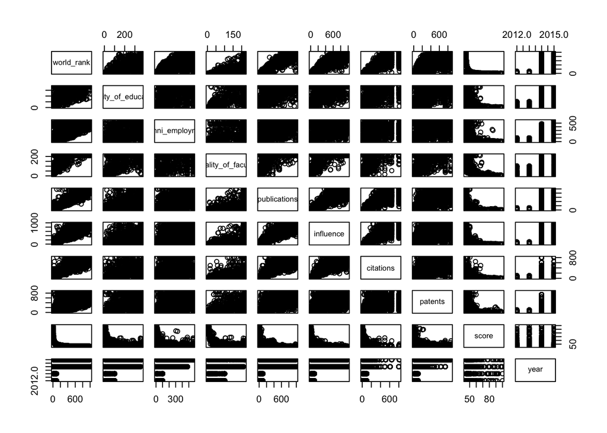

```r
pairs(newpQData)
```

Comment: Creating objects that store information about correlation coefficients using different methods

```r
cr1 <- cor(newpQData, method = "pearson")
cr2 <- cor(newpQData, method = "spearman")
cr3 <- cor(newpQData, method = "kendall")
```

Comments: Plots

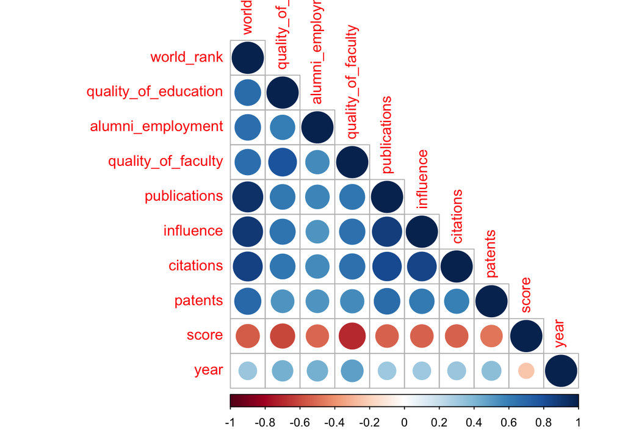

```r
par(mfrow = c(1, 1))
library(corrplot)
corrplot(cr1, type = "lower")
```

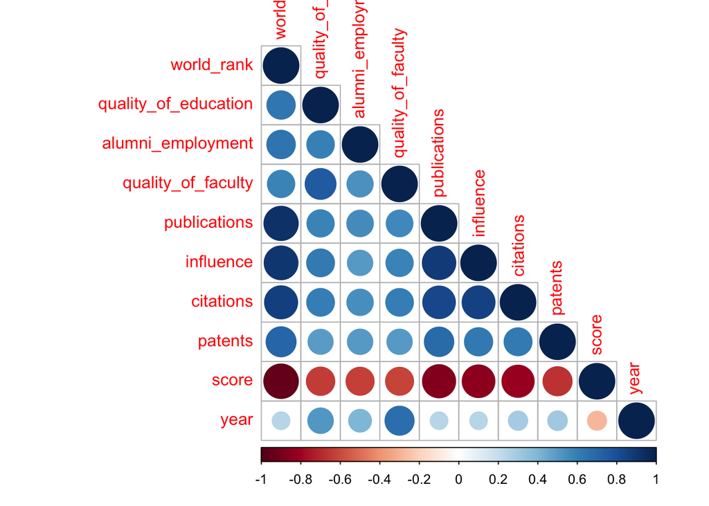

```r
corrplot(cr2, type = "lower")
```

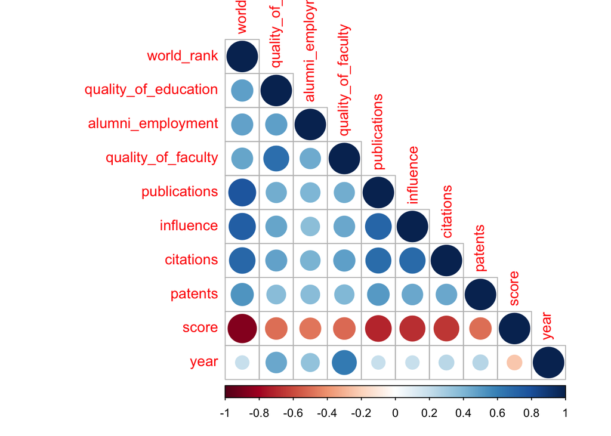

```r
corrplot(cr3, type = "lower")
```

Comments: As we see, publications, influence and citations are dominant factors in getting a good world rank. As the publications, influence and citations in any university decreases, the university gets a better world rank. As the score increases, the rank gets better.

Splitting the data into training and test data

```r
index_cwur <- 1:nrow(cwur)
testindex_cwur <- sample(index_cwur, trunc(length(index_cwur)/5))
testset_cwur <- cwur[testindex_cwur,]
trainset_cwur <- cwur[-testindex_cwur,]
```

Comments: Models

```r
model1 <- lm(world_rank~publications+influence+citations+patents, data = trainset_cwur)
summary(model1)
```

```
##
## Call:
## lm(formula = world_rank ~ publications + influence + citations +
##     patents, data = trainset_cwur)
##
## Residuals:
##     Min      1Q  Median      3Q     Max
## -830.08  -30.82   11.12   46.82  387.43
##
## Coefficients:
##               Estimate Std. Error t value Pr(>|t|)
## (Intercept)  -16.06699    4.69067  -3.425 0.000628 ***
## publications   0.46107    0.01750  26.339  < 2e-16 ***
## influence      0.28445    0.01763  16.130  < 2e-16 ***
## citations      0.18830    0.01714  10.987  < 2e-16 ***
## patents        0.12579    0.01142  11.011  < 2e-16 ***
## ---
## Signif. codes:  0 '***' 0.001 '**' 0.01 '*' 0.05 '.' 0.1 ' ' 1
##
## Residual standard error: 96.42 on 1755 degrees of freedom
## Multiple R-squared:  0.8996, Adjusted R-squared:  0.8994
## F-statistic:  3931 on 4 and 1755 DF,  p-value: < 2.2e-16
```

```r
model2 <- lm(world_rank~alumni_employment+quality_of_education, data = trainset_cwur)
summary(model2)
```

```
##
## Call:
## lm(formula = world_rank ~ alumni_employment + quality_of_education,
##     data = trainset_cwur)
##
## Residuals:
##    Min     1Q Median     3Q    Max
## -671.9 -135.6   -0.2  142.3  514.7
##
## Coefficients:
##                       Estimate Std. Error t value Pr(>|t|)
## (Intercept)          -75.76397   12.31792  -6.151 9.53e-10 ***
## alumni_employment      0.66633    0.03216  20.718  < 2e-16 ***
## quality_of_education   1.07866    0.04914  21.949  < 2e-16 ***
## ---
## Signif. codes:  0 '***' 0.001 '**' 0.01 '*' 0.05 '.' 0.1 ' ' 1
##
## Residual standard error: 200.4 on 1757 degrees of freedom
## Multiple R-squared:  0.5657, Adjusted R-squared:  0.5652
## F-statistic:  1144 on 2 and 1757 DF,  p-value: < 2.2e-16
```

Comments: Predicting using models made

```r
pred_lm1 <- predict(model1, data = testset_cwur)
summary(pred_lm1)
```

```
##    Min. 1st Qu.  Median    Mean 3rd Qu.    Max.
##  -14.88  192.48  476.33  461.77  722.51  970.44
```

```r
pred_lm1 <- cbind(pred_lm1, testset_cwur$world_rank)
View(pred_lm1)
pred_lm2 <- predict(model2, data = testset_cwur)
summary(pred_lm2)
```

```
##    Min. 1st Qu.  Median    Mean 3rd Qu.    Max.
##  -74.02  319.65  547.11  461.77  625.67  697.92
```

```r
pred_lm2 <- cbind(pred_lm2, testset_cwur$world_rank)
View(pred_lm2)
```

Comments: As we see, the prediction of rank using linear regression method is highly inaccurate, So we will have to find out other modelling techniques to predict the rank of universities.

```r
range(times$year)
```

```
## [1] 2011 2016
```

```r
times_sub <- subset(times, country = "United States of America")
str(times_sub)
```

```
## 'data.frame':    2603 obs. of  14 variables:
##  $ world_rank            : Factor w/ 250 levels "=101","=104",..: 39 150 168 182 194 206 206 229 240 40 ...
##  $ university_name       : Factor w/ 818 levels "Aalborg University",..: 161 55 259 419 364 536 671 528 176 809 ...
##  $ country               : Factor w/ 72 levels "Argentina","Australia",..: 71 71 71 71 71 70 70 71 70 71 ...
##  $ teaching              : num  99.7 97.7 97.8 98.3 90.9 90.5 88.2 84.2 89.2 92.1 ...
##  $ international         : Factor w/ 804 levels "-","100.0","12.2",..: 582 409 671 162 564 627 622 263 739 454 ...
##  $ research              : num  98.7 98 91.4 98.1 95.4 94.1 93.9 99.3 94.5 89.7 ...
##  $ citations             : num  98.8 99.9 99.9 99.2 99.9 94 95.1 97.8 88.3 91.5 ...
##  $ income                : Factor w/ 613 levels "-","100.0","24.2",..: 98 515 537 380 1 314 447 1 567 1 ...
##  $ total_score           : Factor w/ 415 levels "-","41.4","41.5",..: 415 414 413 408 407 389 389 388 385 379 ...
##  $ num_students          : Factor w/ 795 levels "","1,211","1,283",..: 292 281 43 169 739 249 275 577 155 61 ...
##  $ student_staff_ratio   : num  8.9 6.9 9 7.8 8.4 11.8 11.6 16.4 11.7 4.4 ...
##  $ international_students: Factor w/ 54 levels "","0%","1%","10%",..: 20 22 29 17 22 30 30 9 46 15 ...
##  $ female_male_ratio     : Factor w/ 70 levels "","-","1 : 99",..: 1 27 31 36 39 40 40 44 31 44 ...
##  $ year                  : int  2011 2011 2011 2011 2011 2011 2011 2011 2011 2011 ...
```

```r
sum(is.na(times_sub))
```

```
## [1] 59
```

```r
times_sub$world_rank<-as.numeric(times_sub$world_rank)
times_sub$num_students<-as.numeric(times_sub$num_students)
times_sub$income<-as.numeric(times_sub$income)
times_sub$international <-as.numeric(times_sub$international)
times_sub$total_score<-as.numeric(times_sub$total_score)
```

Comments: Piping

```r
library(dplyr)
View(times_sub %>% group_by(times_sub$world_rank) %>%
  tally %>% arrange(desc(n)))
```

Comments: Correlation and Correlation Plots

```r
cor(times_sub[c(1,4,5,6,7,8,9,10)])
```

```
##               world_rank    teaching international    research
## world_rank     1.0000000 -0.14682180   -0.20345521 -0.18484832
## teaching      -0.1468218  1.00000000    0.12803265  0.91311979
## international -0.2034552  0.12803265    1.00000000  0.23875642
## research      -0.1848483  0.91311979    0.23875642  1.00000000
## citations     -0.2936498  0.50386668    0.31512921  0.52526356
## income        -0.0555749  0.18848222    0.05596786  0.24915247
## total_score   -0.1135849  0.89155592    0.27130083  0.90762925
## num_students   0.0200713  0.07710711   -0.14322600  0.06323471
##                  citations       income total_score num_students
## world_rank    -0.293649823 -0.055574897 -0.11358489  0.020071296
## teaching       0.503866679  0.188482221  0.89155592  0.077107105
## international  0.315129209  0.055967863  0.27130083 -0.143225998
## research       0.525263562  0.249152466  0.90762925  0.063234712
## citations      1.000000000  0.007640611  0.64515771  0.008378605
## income         0.007640611  1.000000000  0.14278953  0.024757511
## total_score    0.645157712  0.142789525  1.00000000  0.043320018
## num_students   0.008378605  0.024757511  0.04332002  1.000000000
```

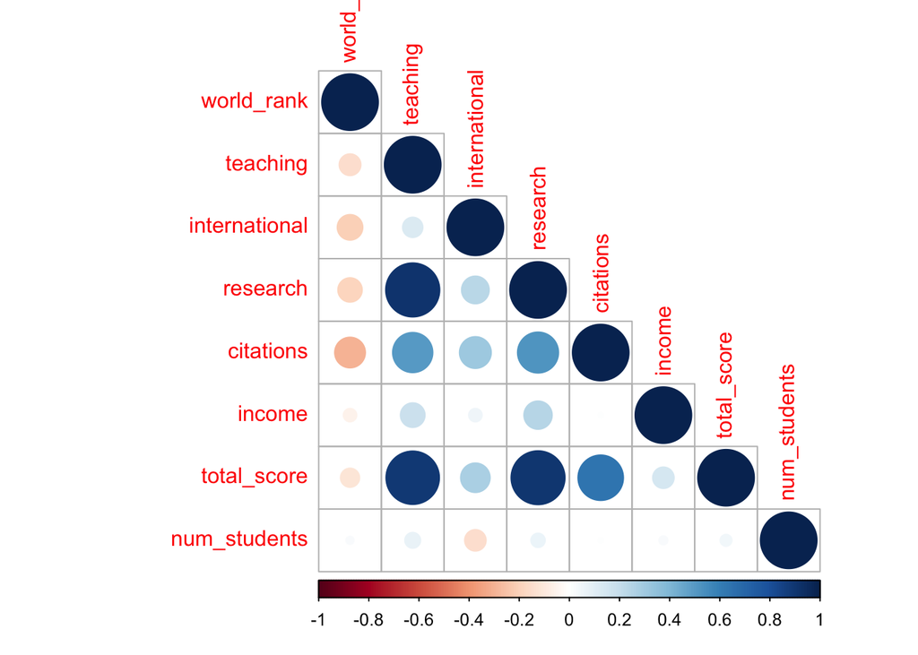

```r
corrplot(cor(times_sub[c(1,4,5,6,7,8,9,10)]), type = "lower")
```

Comments: As we see world rank does not have any strong positive or negative correlation with any other factors. However, research and teaching are highly correlated. Teaching and research have a dominant role in getting better total score.

Plot for dominants factors

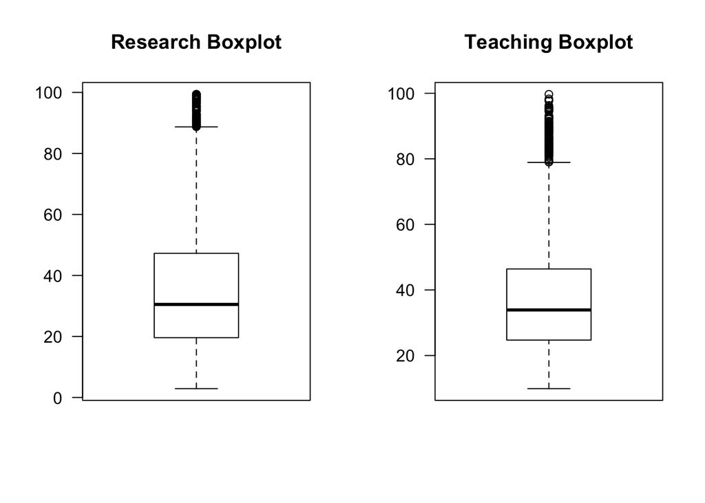

```r
par(mfrow = c(1, 2))
boxplot(times_sub$research, main = "Research Boxplot", las = 1)
boxplot(times_sub$teaching, main = "Teaching Boxplot", las = 1)
```

```r
par(mfrow = c(1, 1))
```

Comments: Making an subset for universities with above average income and teaching quality

```r
summary(times_sub$income)
```

```
##    Min. 1st Qu.  Median    Mean 3rd Qu.    Max.
##     1.0    61.0   139.0   189.2   272.5   613.0
```

```r
best_uni<-subset(times_sub,times_sub$income > 200 & times_sub$teaching > 40)
dim(best_uni)
```

```
## [1] 395  14
```

```r
a <- aggregate(
  best_uni$income,
  by = list(best_uni$teaching),
  FUN = mean,
  na.rm = TRUE
)
View(a)
```

Comment: ### Update after Midterm Deliverable-

Logistic Regression Models to predict whether the university is a top ranked university or not.

Finding the years through which data is present

```r
range(cwur$year)
```

```
## [1] 2012 2015
```

Comment: Subsetting data for each year

```r
j_2012 <- cwur[cwur$year == 2012,]
j_2013 <- cwur[cwur$year == 2013,]
j_2014 <- cwur[cwur$year == 2014,]
j_2015 <- cwur[cwur$year == 2015,]
```

Comment: Finding the number of observations in each year

```r
dim(j_2012)
```

```
## [1] 100  14
```

```r
dim(j_2013)
```

```
## [1] 100  14
```

```r
dim(j_2014)
```

```
## [1] 1000   14
```

```r
dim(j_2015)
```

```
## [1] 1000   14
```

Comment: Finding the range of world rank

```r
range(j_2014$world_rank)
```

```
## [1]    1 1000
```

```r
range(j_2015$world_rank)
```

```
## [1]    1 1000
```

Comment: Creating a new column to tell whether the university is in top 150 world rank or not.

```r
j <- cwur
j$top_rank <- ifelse(cwur$world_rank > 150, 0, 1)
dim(j)
```

```
## [1] 2200   15
```

```r
dim(cwur)
```

```
## [1] 2200   14
```

```r
j_2014$top_rank <- ifelse(j_2014$world_rank > 150, 0, 1)
j_2015$top_rank <- ifelse(j_2015$world_rank > 150, 0, 1)
```

Comment: Logistic Regression Model-

Seperating complete dataset into training dataset and test dataset-

```r
set.seed(7658)
index <- sample(2, nrow(j), replace = T, prob = c(0.7, 0.3))
train.data <- j[index == 1, ]
View(train.data)
test.data <- j[index == 2, ]
View(test.data)
```

Comment: Models, Predictions, Error Matrix and Accuracy-

```r
lr1 <- glm(top_rank ~ quality_of_education + alumni_employment + quality_of_faculty + score, data = train.data)
pred1 <- predict(lr1, test.data, type = "response")
range(pred1)
```

```
## [1] -0.07873301  1.29205854
```

```r
pred1 <- ifelse(pred1 > 0.7, 1, 0)
t1 <- table(pred1, test.data$top_rank)
t1
```

```
##
## pred1   0   1
##     0 502  60
##     1   0  90
```

```r
sum(diag(t1))/sum(t1)
```

```
## [1] 0.9079755
```

Comment: As we see, the accuracy of the above model is around 90%.

```r
lr2 <- glm(top_rank ~ publications + influence + citations + patents, data = train.data)
pred2 <- predict(lr2, test.data, type = "response")
range(pred2)
```

```
## [1] -0.3302133  0.7510828
```

```r
pred2 <- ifelse(pred2 > 0.45, 1, 0)
t2 <- table(pred2, test.data$top_rank)
t2
```

```
##
## pred2   0   1
##     0 462  10
##     1  40 140
```

```r
sum(diag(t2))/sum(t2)
```

```
## [1] 0.9233129
```

Comment: As we see, the accuracy of the above model is around 92%.

Partitioning complete dataset into training and testing dataset-

```r
set.seed(7658)
index_2014 <- sample(2, nrow(j_2014), replace = T, prob = c(0.7, 0.3))
train.data_2014 <- j_2014[index_2014 == 1, ]
test.data_2014 <- j_2014[index_2014 == 2, ]

set.seed(7658)
index_2015 <- sample(2, nrow(j_2015), replace = T, prob = c(0.7, 0.3))
train.data_2015 <- j_2014[index_2015 == 1, ]
test.data_2015 <- j_2014[index_2015 == 2, ]
```

## Comment: Logistic Regression Models, Predictions, Error Matrix and Accuracy-

```r
lr_2014 <- glm(top_rank ~ publications + influence + citations + patents, data = train.data_2014)
pred_2014 <- predict(lr_2014, test.data_2014, type = "response")
range(pred_2014)
```

```
## [1] -0.2491017  0.6582793
```

```r
pred_2014 <- ifelse(pred_2014 > 0.4, 1, 0)
length(pred_2014)
```

```
## [1] 296
```

```r
length(test.data_2014$top_rank)
```

```
## [1] 296
```

```r
t_2014 <- table(pred_2014, test.data_2014$top_rank)
t_2014
```

```
##
## pred_2014   0   1
##         0 238   3
##         1  21  34
```

```r
sum(diag(t_2014))/sum(t_2014)
```

```
## [1] 0.9189189
```

```r
lr_2015 <- glm(top_rank ~ quality_of_education + alumni_employment + quality_of_faculty + score, data = train.data_2015)
pred_2015 <- predict(lr_2015, test.data_2015, type = "response")
range(pred_2015)
```

```
## [1] -0.02351065  1.60032475
```

```r
pred_2015 <- ifelse(pred_2015 > 0.38, 1, 0)
length(pred_2015)
```

```
## [1] 296
```

```r
length(test.data_2015$top_rank)
```

```
## [1] 296
```

```r
t_2015 <- table(pred_2015, test.data_2015$top_rank)
t_2015
```

```
##
## pred_2015   0   1
##         0 250   8
##         1   9  29
```

```r
sum(diag(t_2015))/sum(t_2015)
```

```
## [1] 0.9425676
```

Comment: Logistic regression for American Universities-

```r
j_2012 <- cwur[cwur$year == 2012,]
j_2013 <- cwur[cwur$year == 2013,]
j_2014 <- cwur[cwur$year == 2014,]
j_2015 <- cwur[cwur$year == 2015,]

j_2014_USA <- j_2014[j_2014$country == "USA",]
j_2015_USA <- j_2015[j_2015$country == "USA",]

dim(j_2014_USA)
```

```
## [1] 229  14
```

```r
dim(j_2015_USA)
```

```
## [1] 229  14
```

```r
j_2014_USA$top_rank <- ifelse(j_2014_USA$national_rank > 40, 0, 1)
j_2015_USA$top_rank <- ifelse(j_2015_USA$national_rank > 40, 0, 1)
```

Comment: Partitioning Data

```r
set.seed(7658)
index <- sample(2, nrow(j_2014_USA), replace = T, prob = c(0.7, 0.3))
train.data_2014 <- j_2014_USA[index == 1, ]
test.data_2014 <- j_2014_USA[index == 2, ]

set.seed(7658)
index <- sample(2, nrow(j_2015_USA), replace = T, prob = c(0.7, 0.3))
train.data_2015 <- j_2015_USA[index == 1, ]
test.data_2015 <- j_2015_USA[index == 2, ]
```

Comment: Logistic Regression Models-

```r
lr5 <- glm(top_rank ~ quality_of_education + alumni_employment + quality_of_faculty + score, data = train.data_2014)
pred5 <- predict(lr5, test.data_2014, type = "response")
range(pred5)
```

```
## [1] -0.05795278  1.28914553
```

```r
pred5 <- ifelse(pred5 > 0.95, 1, 0)
t5 <- table(pred5, test.data_2014$top_rank)
t5
```

```
##
## pred5  0  1
##     0 52 10
##     1  0  2
```

```r
sum(diag(t5))/sum(t5)
```

```
## [1] 0.84375
```

Comment: As we see, the accuracy of the above model is around 84.375%.

```r
lr6 <- glm(top_rank ~ publications + influence + citations + patents, data = train.data_2014)
pred6 <- predict(lr6, test.data_2014, type = "response")
range(pred6)
```

```
## [1] -0.2850844  0.4694362
```

```r
pred6 <- ifelse(pred6 > 0.45, 1, 0)
t6 <- table(pred6, test.data_2014$top_rank)
t6
```

```
##
## pred6  0  1
##     0 52  8
##     1  0  4
```

```r
sum(diag(t6))/sum(t6)
```

```
## [1] 0.875
```

Comment: As we see, the accuracy of the above model is around 87.5%.

```r
lr7 <- glm(top_rank ~ quality_of_education + alumni_employment + quality_of_faculty + score, data = train.data_2015)
pred7 <- predict(lr7, test.data_2015, type = "response")
range(pred7)
```

```
## [1] -0.05206246  1.24601942
```

```r
pred7 <- ifelse(pred7 > 0.95, 1, 0)
t7 <- table(pred7, test.data_2015$top_rank)
t7
```

```
##
## pred7  0  1
##     0 52 10
##     1  0  2
```

```r
sum(diag(t7))/sum(t7)
```

```
## [1] 0.84375
```

Comment: As we see, the accuracy of the above model is around 84%.

```r
lr8 <- glm(top_rank ~ publications + influence + citations + patents, data = train.data_2015)
pred8 <- predict(lr8, test.data_2015, type = "response")
range(pred8)
```

```
## [1] -0.2811747  0.4556962
```

```r
pred8 <- ifelse(pred8 > 0.45, 1, 0)
t8 <- table(pred8, test.data_2015$top_rank)
t8
```

```
##
## pred8  0  1
##     0 52 11
##     1  0  1
```

```r
sum(diag(t8))/sum(t8)
```

```
## [1] 0.828125
```

Comment: As we see, the accuracy of the above model is around 82%.

From the above models for the year 2014 and 2015, we can say that accuracy of resesarch based as well as employement based models remain approximately sinmilar over the years.

Logistic regression using times dataset-

```r
range(times$year)
```

```
## [1] 2011 2016
```

```r
sum(times$year == 2011)
```

```
## [1] 200
```

```r
sum(times$year == 2012)
```

```
## [1] 402
```

```r
sum(times$year == 2013)
```

```
## [1] 400
```

```r
sum(times$year == 2014)
```

```
## [1] 400
```

```r
sum(times$year == 2015)
```

```
## [1] 401
```

```r
sum(times$year == 2016)
```

```
## [1] 800
```

```r
levels(times$world_rank)
```

```
##   [1] "=101"    "=104"    "=106"    "=110"    "=113"    "=120"    "=123"
##   [8] "=125"    "=127"    "=131"    "=133"    "=138"    "=144"    "=149"
##  [15] "=158"    "=161"    "=164"    "=167"    "=172"    "=176"    "=180"
##  [22] "=182"    "=185"    "=190"    "=193"    "=196"    "=39"     "=44"
##  [29] "=47"     "=56"     "=60"     "=65"     "=76"     "=82"     "=88"
##  [36] "=90"     "=94"     "=99"     "1"       "10"      "100"     "101"
##  [43] "102"     "103"     "104"     "105"     "106"     "107"     "108"
##  [50] "109"     "11"      "110"     "111"     "112"     "113"     "114"
##  [57] "115"     "116"     "117"     "118"     "119"     "12"      "120"
##  [64] "121"     "122"     "123"     "124"     "125"     "126"     "127"
##  [71] "128"     "129"     "13"      "130"     "131"     "132"     "133"
##  [78] "134"     "135"     "136"     "137"     "138"     "139"     "14"
##  [85] "140"     "141"     "142"     "143"     "144"     "145"     "146"
##  [92] "147"     "148"     "149"     "15"      "150"     "151"     "152"
##  [99] "153"     "154"     "155"     "156"     "157"     "158"     "159"
```

[output cut: 21 more lines]

```r
times$top_rank <- ifelse(as.numeric(times$world_rank) < 150, 1, 0)

sum(times$top_rank == 1)
```

```
## [1] 689
```

```r
sum(times$top_rank == 0)
```

```
## [1] 1914
```

Comment: Data type changing-

```r
times$teaching <- as.numeric(times$teaching)
times$international <- as.numeric(times$international)
times$research <- as.numeric(times$research)
times$citations <- as.numeric(times$citations)
times$income <- as.numeric(times$income)
times$total_score <- as.numeric(times$total_score)
times$num_students <- as.numeric(times$num_students)
times$student_staff_ratio <- as.numeric(times$student_staff_ratio)
```

Comment: Splitting-

```r
set.seed(7658)
index <- sample(2, nrow(times), replace = T, prob = c(0.7, 0.3))
train.data_times <- times[index == 1, ]
test.data_times <- times[index == 2, ]
```

Comment: Models, Prediction, Error Matrix and Accuracy-

```r
lr9 <- glm(top_rank ~ teaching + international + research + citations + income + total_score + num_students + student_staff_ratio, data = train.data_times)
pred9 <- predict(lr9, test.data_times, type = "response")
summary(pred9)
```

```
##    Min. 1st Qu.  Median    Mean 3rd Qu.    Max.    NA's
## -0.5738  0.1797  0.3225  0.2636  0.3880  0.5601      14
```

```r
pred9 <- ifelse(pred9 > 0.38, 1, 0)
t9 <- table(pred9, test.data_times$top_rank)
t9
```

```
##
## pred9   0   1
##     0 454  98
##     1 110 103
```

```r
sum(diag(t9))/sum(t9)
```

```
## [1] 0.7281046
```

Comment: As we see, the accuracy of this model is around 72%.

```r
lr10 <- glm(top_rank ~ teaching + international + income + num_students + student_staff_ratio, data = train.data_times)
pred10 <- predict(lr10, test.data_times, type = "response")
summary(pred10)
```

```
##    Min. 1st Qu.  Median    Mean 3rd Qu.    Max.    NA's
## -0.2526  0.1776  0.2490  0.2654  0.3410  0.6624      14
```

```r
pred10 <- ifelse(pred10 > 0.34, 1, 0)
t10 <- table(pred10, test.data_times$top_rank)
t10
```

```
##
## pred10   0   1
##      0 453 117
##      1 111  84
```

```r
sum(diag(t10))/sum(t10)
```

```
## [1] 0.7019608
```

Comment: Accuracy of the employement based logistic regreeion model is around 70%.

```r
lr11 <- glm(top_rank ~ research + citations + total_score, data = train.data_times)
pred11 <- predict(lr11, test.data_times, type = "response")
summary(pred11)
```

```
##    Min. 1st Qu.  Median    Mean 3rd Qu.    Max.
## -0.2478  0.1825  0.3150  0.2630  0.3775  0.5738
```

```r
pred11 <- ifelse(pred11 > 0.37, 1, 0)
t11 <- table(pred11, test.data_times$top_rank)
t11
```

```
##
## pred11   0   1
##      0 447 124
##      1 128  80
```

```r
sum(diag(t11))/sum(t11)
```

```
## [1] 0.6765083
```

Comment: As we see, this model has the least accuracy amog all the models developed uptill now which is 67%.

Logistic Regression using Shanghai dataset-

```r
levels(shanghai$world_rank)
```

```
##   [1] "1"       "10"      "100"     "101-150" "101-151" "101-152" "102-150"
##   [8] "11"      "12"      "13"      "14"      "15"      "151-200" "151-202"
##  [15] "152-200" "153-202" "16"      "17"      "18"      "19"      "2"
##  [22] "20"      "201-300" "201-302" "203-300" "203-304" "21"      "22"
##  [29] "23"      "24"      "25"      "26"      "27"      "28"      "29"
##  [36] "3"       "30"      "301-400" "303-401" "305-402" "31"      "32"
##  [43] "33"      "34"      "35"      "36"      "37"      "38"      "39"
##  [50] "4"       "40"      "401-500" "402-501" "402-503" "403-510" "41"
##  [57] "42"      "43"      "44"      "45"      "46"      "47"      "48"
##  [64] "49"      "5"       "50"      "51"      "52"      "53"      "54"
##  [71] "55"      "56"      "57"      "58"      "59"      "6"       "60"
##  [78] "61"      "62"      "63"      "64"      "65"      "66"      "67"
##  [85] "68"      "69"      "7"       "70"      "71"      "72"      "73"
##  [92] "74"      "75"      "76"      "77"      "78"      "79"      "8"
##  [99] "80"      "81"      "82"      "83"      "84"      "85"      "86"
## [106] "87"      "88"      "89"      "9"       "90"      "91"      "92"
## [113] "93"      "94"      "95"      "96"      "97"      "98"      "99"
```

Comment: Alloting binary levels-

```r
shanghai$top_rank <- ifelse(as.numeric(shanghai$world_rank) < 100, 1, 0)
```

Comment: Changing the data type of each column to numeric-

```r
shanghai$world_rank <- as.numeric(shanghai$world_rank)
shanghai$total_score <- as.numeric(shanghai$total_score)
shanghai$alumni <- as.numeric(shanghai$alumni)
shanghai$award <- as.numeric(shanghai$award)
shanghai$hici <- as.numeric(shanghai$hici)
shanghai$ns <- as.numeric(shanghai$ns)
shanghai$pub <- as.numeric(shanghai$pub)
shanghai$pcp <- as.numeric(shanghai$pcp)
```

Comment: Splitting-

```r
set.seed(7658)
index <- sample(2, nrow(shanghai), replace = T, prob = c(0.7, 0.3))
train.data_shanghai <- shanghai[index == 1, ]
test.data_shanghai <- shanghai[index == 2, ]
```

Comment: Model-

```r
lr12 <- glm(top_rank ~ total_score + alumni + award + hici + ns + pub + pcp, data = train.data_shanghai)
pred12 <- predict(lr12, test.data_shanghai, type = "response")
summary(pred12)
```

```
##    Min. 1st Qu.  Median    Mean 3rd Qu.    Max.    NA's
##  0.3966  0.6842  0.7724  0.8048  0.9137  1.5890    1119
```

```r
pred12 <- ifelse(pred12 > 0.91, 1, 0)
t12 <- table(pred12, test.data_shanghai$top_rank)
t12
```

```
##
## pred12   0   1
##      0  65 181
##      1   1  83
```

```r
sum(diag(t12))/sum(t12)
```

```
## [1] 0.4484848
```

Comment: Model has a very low accuracy of around 45%.

Comment: Classifying universities based on a seperate feature created-

Reading Dataset-

```r
cwur <- read.csv("~/Desktop/Data Science 808W/My Project/world-university-rankings/cwurData.csv")
```

Comment: Subsetting Data according to year-

```r
max(cwur$quality_of_education)
```

```
## [1] 367
```

```r
part2 <- subset(cwur, year=="2012", select =c( world_rank:year))
part3 <- subset(cwur, year=="2013", select =c( world_rank:year))
```

Comment: Feature Definition-

```r
cwur$gen_res<-cwur$quality_of_faculty*0.1+cwur$publications*0.3+cwur$citations*0.3+cwur$patents*0.3
```

Comment: Loading required libraries-

```r
library(caret)
library(dplyr)

genres<- cwur$gen_res
max(genres)
```

```
## [1] 821.6
```

```r
min(genres)
```

```
## [1] 1.3
```

Comment: Labels of classes of universities-

```r
my_research <- c("Average","Decent","Very Good","Outstanding")
cwur$cat <- cut(cwur$gen_res,breaks = c(0,200,500,700,Inf),labels = my_research)
```

Comment: Assigning binary levels according to the feature score-

```r
cwur$res<- ifelse(cwur$gen_res > 700,1,0)
```

Comment: Analyzing data for further process-

```r
a <- table(cwur$res)
no_1 <- as.data.frame(a)
```

Comment: Splitting the complete dataset into training and testing dataset-

```r
div <- createDataPartition(y=cwur$res,p=0.7,list = FALSE)
training <- cwur[div,]
testing <- cwur[-div,]
```

Comment: Converting binary datatype to factors-

```r
training[["res"]]= factor(training[["res"]])
testing[["res"]]= factor(testing[["res"]])
```

Comment: Optimization Protocol-

```r
control <- trainControl(method = "repeatedcv", number = 10, repeats = 3)
```

Comment: Model-

```r
mod_1 <- train(res ~quality_of_faculty+publications, data = training, method = "svmLinear",
               trControl=control,
               preProcess = c("center", "scale"),
               tuneLength = 10)
```

Comment: Prediction-

```r
pred_1 <- predict(mod_1, newdata = testing)
```

Comment: Error Matrix-

```r
acc_1 <- confusionMatrix(pred_1, testing$res)
acc_1
```

```
## Confusion Matrix and Statistics
##
##           Reference
## Prediction   0   1
##          0 598  62
##          1   0   0
##
##                Accuracy : 0.9061
##                  95% CI : (0.8812, 0.9272)
##     No Information Rate : 0.9061
##     P-Value [Acc > NIR] : 0.5337
##
##                   Kappa : 0
##  Mcnemar's Test P-Value : 9.408e-15
##
##             Sensitivity : 1.0000
##             Specificity : 0.0000
##          Pos Pred Value : 0.9061
##          Neg Pred Value :    NaN
##              Prevalence : 0.9061
##          Detection Rate : 0.9061
##    Detection Prevalence : 1.0000
##       Balanced Accuracy : 0.5000
##
##        'Positive' Class : 0
##
```

Comment: Increment in features-

```r
mod_2 <- train(res ~quality_of_faculty+publications+citations, data = training, method = "svmLinear",
               trControl=control,
               preProcess = c("center", "scale"),
               tuneLength = 10)

pred_2 <- predict(mod_2, newdata = testing)

acc_2 <- confusionMatrix(pred_2, testing$res)
acc_2
```

```
## Confusion Matrix and Statistics
##
##           Reference
## Prediction   0   1
##          0 573  18
##          1  25  44
##
##                Accuracy : 0.9348
##                  95% CI : (0.9132, 0.9525)
##     No Information Rate : 0.9061
##     P-Value [Acc > NIR] : 0.004998
##
##                   Kappa : 0.6357
##  Mcnemar's Test P-Value : 0.360196
##
##             Sensitivity : 0.9582
##             Specificity : 0.7097
##          Pos Pred Value : 0.9695
##          Neg Pred Value : 0.6377
##              Prevalence : 0.9061
##          Detection Rate : 0.8682
##    Detection Prevalence : 0.8955
##       Balanced Accuracy : 0.8339
##
##        'Positive' Class : 0
##
```

```r
mod_3 <- train(res ~influence, data = training, method = "svmLinear",
               trControl=control,
               preProcess = c("center", "scale"),
               tuneLength = 10)

pred_3 <- predict(mod_3,newdata = testing)
acc_3 <- confusionMatrix(pred_3, testing$res)
acc_3
```

```
## Confusion Matrix and Statistics
##
##           Reference
## Prediction   0   1
##          0 598  62
##          1   0   0
##
##                Accuracy : 0.9061
##                  95% CI : (0.8812, 0.9272)
##     No Information Rate : 0.9061
##     P-Value [Acc > NIR] : 0.5337
##
##                   Kappa : 0
##  Mcnemar's Test P-Value : 9.408e-15
##
##             Sensitivity : 1.0000
##             Specificity : 0.0000
##          Pos Pred Value : 0.9061
##          Neg Pred Value :    NaN
##              Prevalence : 0.9061
##          Detection Rate : 0.9061
##    Detection Prevalence : 1.0000
##       Balanced Accuracy : 0.5000
##
##        'Positive' Class : 0
##
```

Comment: Testing out whether feature is relevant-

```r
mod_4 <- train(res ~quality_of_education, data = training, method = "svmLinear",
               trControl=control,
               preProcess = c("center", "scale"),
               tuneLength = 10)

pred_4 <- predict(mod_4,newdata = testing)

acc_4 <- confusionMatrix(pred_4, testing$res)
acc_4
```

```
## Confusion Matrix and Statistics
##
##           Reference
## Prediction   0   1
##          0 598  62
##          1   0   0
##
##                Accuracy : 0.9061
##                  95% CI : (0.8812, 0.9272)
##     No Information Rate : 0.9061
##     P-Value [Acc > NIR] : 0.5337
##
##                   Kappa : 0
##  Mcnemar's Test P-Value : 9.408e-15
##
##             Sensitivity : 1.0000
##             Specificity : 0.0000
##          Pos Pred Value : 0.9061
##          Neg Pred Value :    NaN
##              Prevalence : 0.9061
##          Detection Rate : 0.9061
##    Detection Prevalence : 1.0000
##       Balanced Accuracy : 0.5000
##
##        'Positive' Class : 0
##
```

```r
mod_5 <-  train(res ~publications+citations+patents, data = training, method = "svmLinear",
                trControl=control,
                preProcess = c("center", "scale"),
                tuneLength = 10)

pred_5 <- predict(mod_5,newdata = testing)

acc_5 <- confusionMatrix(pred_5, testing$res)
acc_5
```

```
## Confusion Matrix and Statistics
##
##           Reference
## Prediction   0   1
##          0 598   0
##          1   0  62
##
##                Accuracy : 1
##                  95% CI : (0.9944, 1)
##     No Information Rate : 0.9061
##     P-Value [Acc > NIR] : < 2.2e-16
##
##                   Kappa : 1
##  Mcnemar's Test P-Value : NA
##
##             Sensitivity : 1.0000
##             Specificity : 1.0000
##          Pos Pred Value : 1.0000
##          Neg Pred Value : 1.0000
##              Prevalence : 0.9061
##          Detection Rate : 0.9061
##    Detection Prevalence : 0.9061
##       Balanced Accuracy : 1.0000
##
##        'Positive' Class : 0
##
```

```r
mod_6 <- train(res ~quality_of_faculty+quality_of_education, data = training, method = "svmLinear",
               trControl=control,
               preProcess = c("center", "scale"),
               tuneLength = 10)

pred_6 <- predict(mod_6, newdata = testing)

acc_6 <- confusionMatrix(pred_6, testing$res)
acc_6
```

```
## Confusion Matrix and Statistics
##
##           Reference
## Prediction   0   1
##          0 598  62
##          1   0   0
##
##                Accuracy : 0.9061
##                  95% CI : (0.8812, 0.9272)
##     No Information Rate : 0.9061
##     P-Value [Acc > NIR] : 0.5337
##
##                   Kappa : 0
##  Mcnemar's Test P-Value : 9.408e-15
##
##             Sensitivity : 1.0000
##             Specificity : 0.0000
##          Pos Pred Value : 0.9061
##          Neg Pred Value :    NaN
##              Prevalence : 0.9061
##          Detection Rate : 0.9061
##    Detection Prevalence : 1.0000
##       Balanced Accuracy : 0.5000
##
##        'Positive' Class : 0
##
```

Comment: Model with less accuracy as compared to the best, one feature is irrelevant.

Visualization-

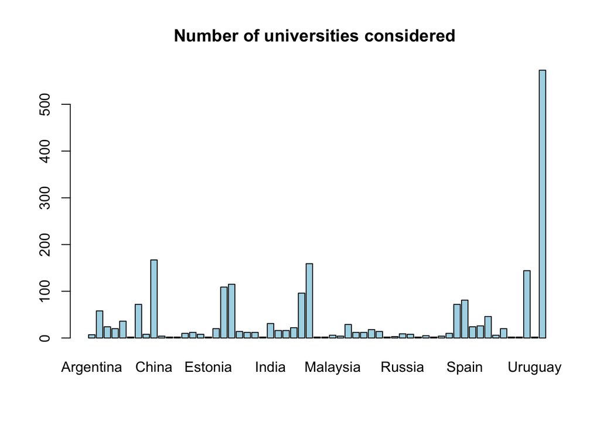

```r
occ <- table(cwur$country)
barplot (occ,main = 'Number of universities considered ',col = 'lightblue')
```

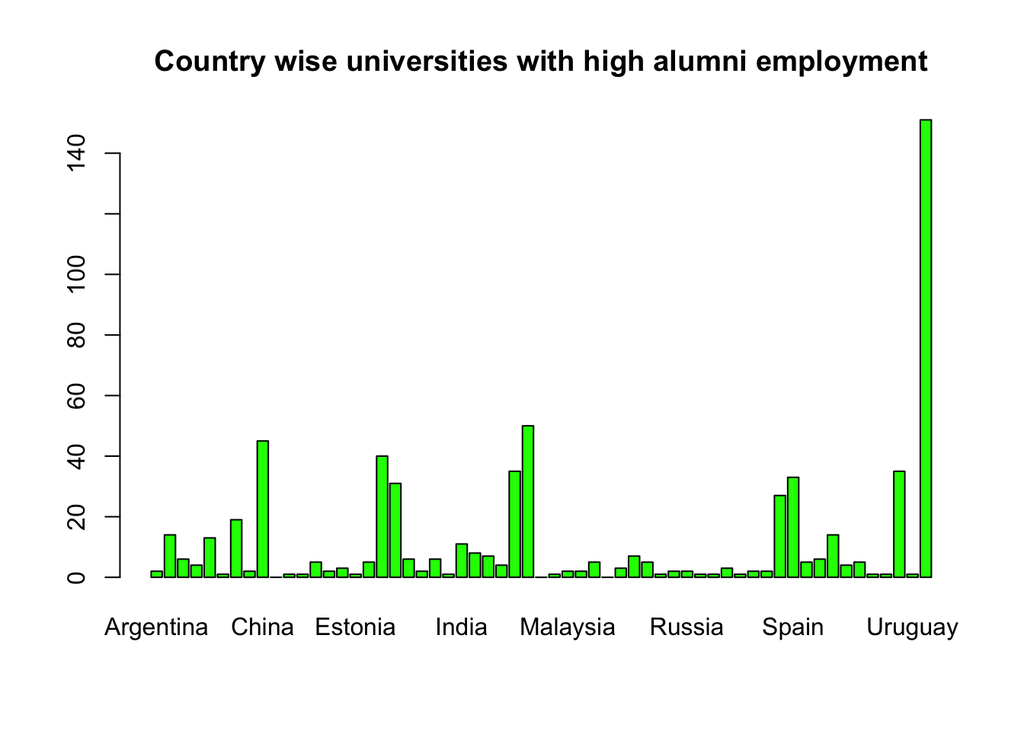

```r
occ2 <- table(cwur$country[cwur$alumni_employment > '500'])
barplot(occ2,main = 'Country wise universities with high alumni employment' ,col= 'green' )
```

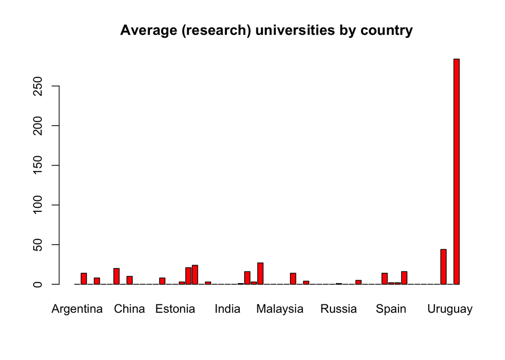

```r
occ3 <- table(cwur$country[cwur$cat=='Average'])
barplot(occ3, main= 'Average (research) universities by country',col = 'red')
```

```r
final_acc1 <- acc_1$overall
final_acc1.accuracy <- final_acc1['Accuracy']
predicted.accuracy <- c(88.78,94.39,86.36,88.79,99.1,88.79)
final_models<- c('mod_1','mod_2','mod_3','mod_4','mod_5','mod_6')

featur <- cbind(final_models,predicted.accuracy)
featur<-  data.frame(featur)
```

Comment: Accuracy comparision Plots-

[figure not shown]

```r
ggplot(featur, aes(final_models, predicted.accuracy))+geom_bar(stat="identity",color='blue')+xlab("SVM models")+ylab("Accuracy")
```